# Lab 2 - Checkpoint 4 - Andreza Raquel

## Realizando uma análise exploratória em um sample de log de eventos da Wikimedia Foundation

O objetivo desse documento é realizar uma análise nos dados de eventos (event logging (EL)) capturados pela Wikimedia Foundation.

O conjunto de dados vem de um esquema de rastreamento usado na empresa para avaliar a satisfação do usuário. Os usuários são escolhidos aleatoriamente para serem rastreados anonimamente por esse esquema que usa um sistema de ping “Estou vivo”, que permite estimar por quanto tempo os usuários permanecem nas páginas que visitam. O conjunto de dados contém apenas pouco mais de uma semana de dados de EL.

Nossa análise busca tocar nos seguintes pontos:

- Qual é a taxa de cliques geral diária? Como isso varia entre os grupos?
- Quais resultados as pessoas tendem a tentar primeiro? Como isso muda no dia-a-dia?
- Qual é a taxa de resultados zero no geral? Como isso varia entre os grupos?
- A duração da sessão é aproximadamente o tempo entre o primeiro e o último evento de uma sessão. Escolha uma variável do conjunto de dados e descreva sua relação com o tamanho da sessão. Visualize o relacionamento.

Durante todo documento, vamos utilizar conceitos de marcas e canais, para isso vamos definir o que eles significam:

- **Marcas:** são as primitivas gráficas através das quais a informação é transmitida. Podem ser pontos, colunas, áreas, etc.
- **Canais:** são os parâmetros das primitivas. Podem ser: posição (horizontal, vertical), a cor, o tamanho, etc.

O objetivo é entendermos como a utilização de diferentes marcas e canais influencia na eficácia da visualização.

### Importando as bibliotecas necessárias e lendo os dados

```r
library(tidyverse)
library(here)
library(lubridate)
library(knitr)
library(ggplot2)
theme_set(theme_bw())
```

Após importar as bibliotecas acima, vamos ler os dados que foram formatados e salvos no documento search_data.csv. Esse documento contém as seguintes colunas:

- **session_id:** Um ID exclusivo que identifica sessões individuais;
- **search_index:** Número da busca realizada pelo usuário na sessão;
- **session_start_timestamp:** Timestamp do início da pesquisa;
- **session_end_timestamp:** Timestamp do fim da pesquisa;
- **session_start_date:** Data e hora do início da pesquisa;
- **session_end_date:** Data e hora do fim da pesquisa;
- **checkin:** Por quanto tempo a página permaneceu aberta;
- **group:** Um label (“a” ou “b”);
- **results:** Número de ocorrências retornadas ao usuário;
- **num_clicks:** Número de ocorrências clicadas pelo usuário;
- **first_click:** Posição da ocorrência que o usuário clicou primeiro.

```r
buscas = read_csv(here::here("data/search_data.csv"))
```

Agora, vamos adicionar mais uma coluna aos dados para facilitar as visualizações. Essa coluna vai se chamar *date* e será a data do início da pesquisa, sem conter a hora que ela aconteceu. Será derivada da coluna já existente *session_start_timestamp*.

```r
buscas = buscas  %>%
  mutate(
    date = as.character(as.Date(round_date(ymd_hms(session_start_timestamp))),
    unit = "day"))
```

Em nossas análises precisaremos que algumas colunas em específico estejam consistentes entre si. É lógico, pelo que sabemos dos dados, que o primeiro clique do usuário só pode ser um número entre 1 e o número de resultados retornado na pesquisa. É fácil perceber também que se o número de cliques for maior ou igual a zero, significa que a coluna *first_click* deve estar devidamente preenchida.

Vejamos se os dados ferem essas premissas:

```r
premissa1 = buscas %>%
  filter(first_click > results )
premissa1
```

| session_id | search_index | session_start_timestamp | session_end_timestamp | session_start_date | session_end_date | checkin | group | results | num_clicks | first_click | date |
| --- | --- | --- | --- | --- | --- | --- | --- | --- | --- | --- | --- |
| 012460df6605630a | 3 | 2.016031e+13 | 2.016031e+13 | 2016-03-07 17:20:49 | 2016-03-07 17:24:32 | 210 | a | 20 | 1 | 21 | 2016-03-07 |
| 0705f6124671c837 | 6 | 2.016031e+13 | 2.016031e+13 | 2016-03-08 06:05:38 | 2016-03-08 06:08:04 | 50 | a | 20 | 1 | 38 | 2016-03-08 |
| 07d1244fb0ecfa18 | 5 | 2.016030e+13 | 2.016030e+13 | 2016-03-04 20:32:29 | 2016-03-04 20:39:57 | 420 | a | 20 | 1 | 94 | 2016-03-04 |
| 0c02236a143c5f2d | 2 | 2.016030e+13 | 2.016030e+13 | 2016-03-04 12:10:50 | 2016-03-04 12:15:58 | 300 | a | 0 | 1 | 1 | 2016-03-04 |
| 0d050fd8343f9ab7 | 2 | 2.016031e+13 | 2.016031e+13 | 2016-03-05 11:48:03 | 2016-03-05 11:50:50 | 150 | a | 12 | 1 | 32 | 2016-03-05 |
| 0d6eb81512d879e9 | 3 | 2.016030e+13 | 2.016030e+13 | 2016-03-02 13:39:10 | 2016-03-02 13:40:21 | 50 | a | 20 | 2 | 34 | 2016-03-02 |
| 10541aaefd0e6edc | 3 | 2.016030e+13 | 2.016030e+13 | 2016-03-03 19:56:01 | 2016-03-03 19:56:13 | NA | a | 2 | 1 | 6 | 2016-03-03 |
| 114e3fa48cc98264 | 3 | 2.016030e+13 | 2.016030e+13 | 2016-03-02 19:18:56 | 2016-03-02 19:19:09 | NA | a | 8 | 1 | 37 | 2016-03-02 |
| 114e3fa48cc98264 | 11 | 2.016030e+13 | 2.016030e+13 | 2016-03-02 19:20:40 | 2016-03-02 19:20:57 | NA | a | 19 | 2 | 27 | 2016-03-02 |
| 12060c71917f4a7a | 1 | 2.016031e+13 | 2.016031e+13 | 2016-03-08 06:25:56 | 2016-03-08 06:26:21 | 10 | b | 1 | 1 | 8 | 2016-03-08 |

[output cut: 310 more lines]

```r
premissa2 =  buscas %>%
  filter(is.na(first_click) & num_clicks > 0)
premissa2
```

| session_id | search_index | session_start_timestamp | session_end_timestamp | session_start_date | session_end_date | checkin | group | results | num_clicks | first_click | date |
| --- | --- | --- | --- | --- | --- | --- | --- | --- | --- | --- | --- |
| 1a9459a338122787 | 1 | 2.01603e+13 | 2.01603e+13 | 2016-03-02 01:11:49 | 2016-03-02 01:16:12 | 240 | a | 20 | 1 | NA | 2016-03-02 |
| 5caa35c50d2f5306 | 2 | 2.01603e+13 | 2.01603e+13 | 2016-03-01 01:07:25 | 2016-03-01 01:07:55 | 20 | a | 1 | 1 | NA | 2016-03-01 |
| ceac717235e5c8de | 2 | 2.01603e+13 | 2.01603e+13 | 2016-03-03 09:45:29 | 2016-03-03 09:56:50 | 120 | a | 2 | 8 | NA | 2016-03-03 |

```r
numero_cliques = buscas %>%
  filter(num_clicks > results)
numero_cliques
```

| session_id | search_index | session_start_timestamp | session_end_timestamp | session_start_date | session_end_date | checkin | group | results | num_clicks | first_click | date |
| --- | --- | --- | --- | --- | --- | --- | --- | --- | --- | --- | --- |
| 01a0d2b3d48278a7 | 1 | 2.016030e+13 | 2.016030e+13 | 2016-03-01 16:01:14 | 2016-03-01 16:12:03 | 150 | a | 1 | 5 | 1 | 2016-03-01 |
| 02aa6878fcdf6c58 | 4 | 2.016030e+13 | 2.016030e+13 | 2016-03-01 04:07:50 | 2016-03-01 04:09:48 | NA | a | 1 | 3 | 1 | 2016-03-01 |
| 056145b0bb0d8b0a | 3 | 2.016030e+13 | 2.016030e+13 | 2016-03-01 10:43:04 | 2016-03-01 10:50:26 | 420 | a | 1 | 2 | 1 | 2016-03-01 |
| 06246aa5920e06ab | 1 | 2.016030e+13 | 2.016030e+13 | 2016-03-01 06:23:57 | 2016-03-01 06:25:38 | NA | a | 3 | 4 | 1 | 2016-03-01 |
| 0904291b33ce4177 | 1 | 2.016030e+13 | 2.016030e+13 | 2016-03-04 00:16:15 | 2016-03-04 00:20:32 | NA | a | 2 | 5 | 1 | 2016-03-04 |
| 0c02236a143c5f2d | 2 | 2.016030e+13 | 2.016030e+13 | 2016-03-04 12:10:50 | 2016-03-04 12:15:58 | 300 | a | 0 | 1 | 1 | 2016-03-04 |
| 0c1c9b34aae59592 | 1 | 2.016030e+13 | 2.016030e+13 | 2016-03-02 14:05:39 | 2016-03-02 14:05:54 | 10 | a | 1 | 2 | 1 | 2016-03-02 |
| 0e3be6c890eac270 | 1 | 2.016030e+13 | 2.016030e+13 | 2016-03-02 19:02:03 | 2016-03-02 19:03:26 | 60 | a | 1 | 2 | 1 | 2016-03-02 |
| 0ea5d74e2d375b1a | 1 | 2.016030e+13 | 2.016030e+13 | 2016-03-02 08:07:40 | 2016-03-02 08:21:17 | 420 | a | 2 | 4 | 2 | 2016-03-02 |
| 0f0da30e8776ad1f | 1 | 2.016030e+13 | 2.016030e+13 | 2016-03-01 03:46:15 | 2016-03-01 03:46:23 | NA | a | 1 | 2 | 1 | 2016-03-01 |

[output cut: 98 more lines]

Aqui vemos que as consultas das premissas acima não retornaram vazias, o que significa que algo está estranho. Analizando os resultados, preferiu-se tirar esses dados “problemáticos” das buscas.

Outro fato interessante observado foi que, em alguns casos, o número de cliques é maior que o número de resultados retornados. O que podemos deduzir disso é que o usuário clicou no mesmo link várias vezes, portanto faz sentido manter esses dados e não considerá-los como “sujeiras”.

Façamos a limpeza dos dados:

```r
buscas = buscas %>%
  filter((first_click <= results) | (is.na(first_click) & num_clicks == 0))
```

Feito isso, vamos começar com a seguinte perguta:

#### Qual é a taxa de cliques geral diária? Como isso varia entre os grupos?

o gráfico abaixo mostra a taxa de cada quantidade de cliques em cada dia presente nos dados. Essa taxa de cliques é a porcentagem de cliques em relação ao total de pesquisas - que retornaram agum resultado - realizadas no dia. Ou seja, a soma das taxas das quantidades de cliques iguais a 0, 1, 2, … ,n de um dia específico é igual a 100%.

Podemos ver que os dados estão concentrados na faixa de 0 a 5 cliques, porque as barras maiores estão nessas posições. Mais especificamente, vemos que as maiores taxas são observadas para a quantidade de cliques igual a zero. As segundas maiores taxas observadas são para a quantidade de cliques igual a 1. Após isso, vemos que as taxas tendem a diminuir. Essas conclusões são observadas em todos os dias presentes nos dados, representados pelas barras de cores diferentes.

A marca utilizada foi a coluna para representar a *taxa de cliques* para cada n, sendo n o *número de cliques*, exibidos nos canais vertical e horizontal, respectivamente. Outra marca inserida foi a marca da cor, onde diferentes cores foram usadas para representar os diferentes dias presentes nos dados. Podemos perceber que ficou difícil identificar quais dias têm taxas maiores ou menores, porque a variável *dia* está codificada em um canal secundário. Veremos como resolver isso adiante.

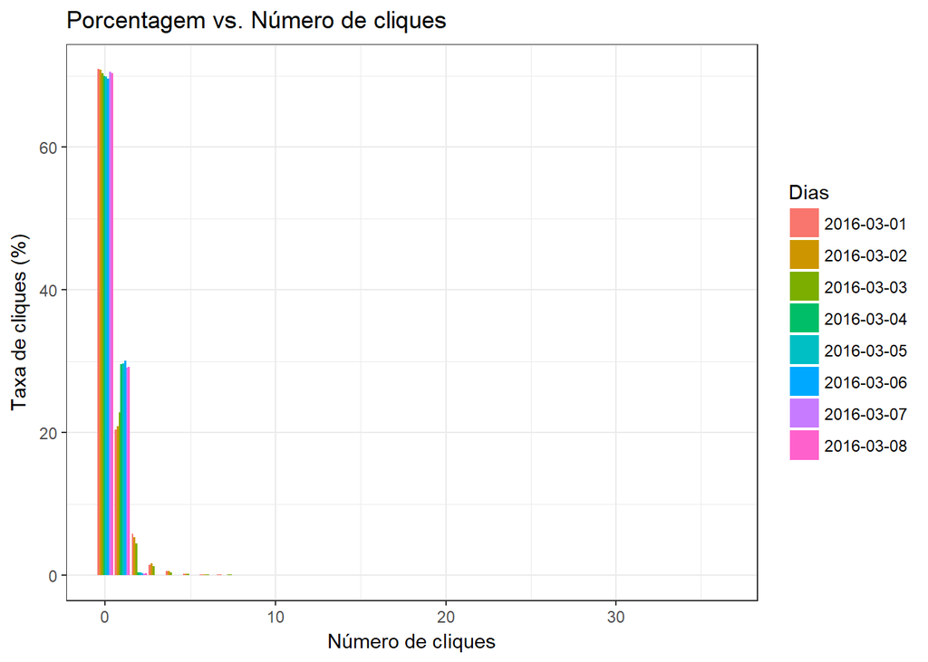

```r
taxa_cliques <- buscas %>%
  filter(results >= 1, !is.na(num_clicks)) %>%
  arrange(date) %>%
  group_by(date, num_clicks) %>%
  summarise(n = n()) %>%
  mutate(taxa_cliques = n / sum(n) * 100)

taxa_cliques %>%
  ggplot(aes(x= num_clicks, y = taxa_cliques, fill = date)) +
  geom_col(position = "dodge") +
  labs(title="Porcentagem vs. Número de cliques",
       x="Número de cliques",
       y="Taxa de cliques (%)",
       fill = "Dias")
```

Para responder à pesqunta da taxa de cliques, precisamos observar a soma das taxas de cliques, onde o número de cliques seja maior que zero. Podemos observar esse resultado abaixo.

Para cada dia presente nos dados, observamos que essa taxa é em torno de 30%, que é a altura das barras. Ou seja, em cerca de 30% das pesquisas realizadas - e que retornaram algum resultado - em cada dia, os usuários clicaram em algum resultado retornado. Esse resultado confirma o que foi observado anteriormente, onde a taxa para o número de cliques igual a zero foi em torno de 70% no gráfico acima.

A marca utilizada foi a coluna, identificando a taxa de cliques, para cada dia. Como, tanto a taxa de cliques quanto os dias foram exibidos em canais principais (vertical e horizontal, respectivamente), a resposta para a pergunta ficou mais clara, pois esses canais são os que o humano consegue perceber com mais naturalidade.

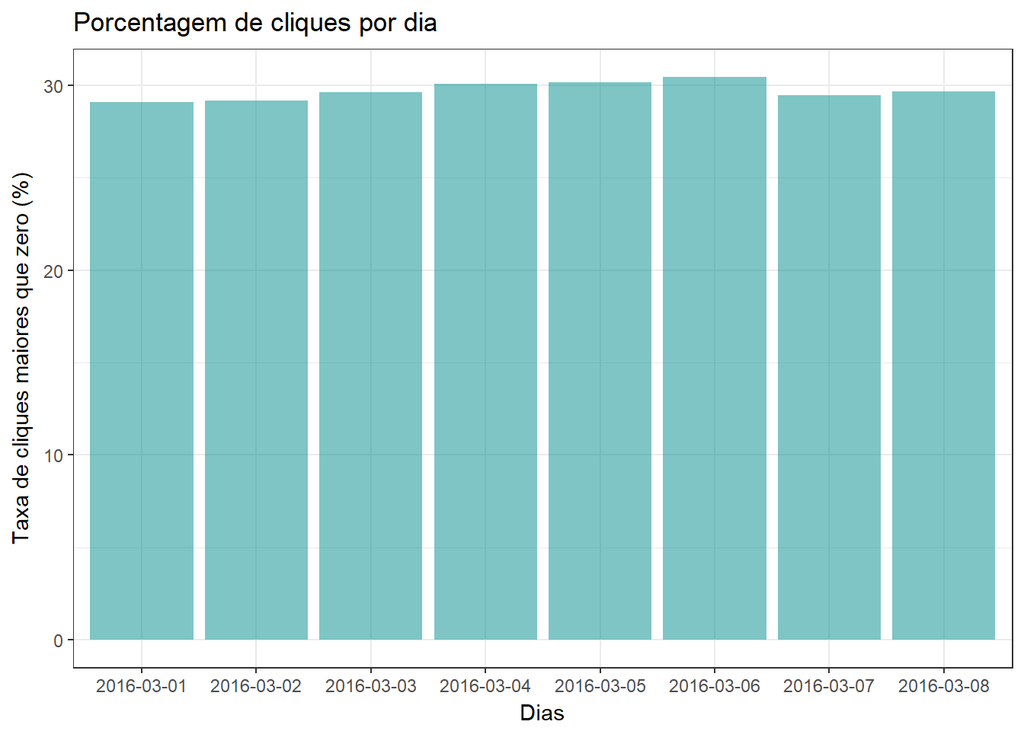

```r
taxa_cliques %>%
  filter(num_clicks > 0) %>%
  ggplot(aes(x = date, y =  taxa_cliques )) +
  geom_col(fill = "darkcyan", alpha = .5) +
  labs(title="Porcentagem de cliques por dia",
       x="Dias",
       y="Taxa de cliques maiores que zero (%)")
```

Ao separarmos os dados por grupos, e fazermos a mesma análise acima, chegamos a resultados diferentes em cada grupo.

Aqui, os canais e marcas utilizadas foram os mesmos da primeira visualização. A diferença é que foi inserida outra variável, o grupo (podendo assumir dois valores : *a* ou *b*). As informações de cada grupo ficaram em um gráfico diferente.

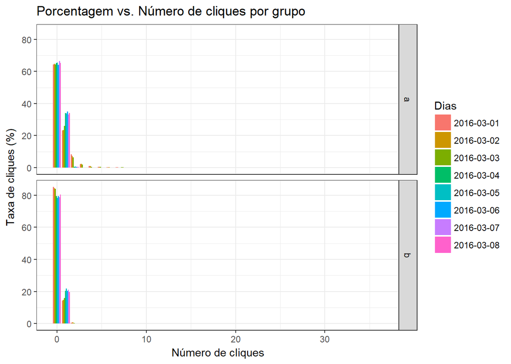

```r
taxa_cliques_group <- buscas %>%
  filter(results >= 1, !is.na(num_clicks)) %>%
  group_by(date, group, num_clicks) %>%
  summarise(n = n()) %>%
  mutate(taxa_cliques_group = n / sum(n) * 100)

taxa_cliques_group %>%
  ggplot(aes(x= num_clicks, y = taxa_cliques_group, fill = date)) +
  geom_col(position = "dodge") +
  facet_grid(group ~ .) +
  labs(title="Porcentagem vs. Número de cliques por grupo",
       x="Número de cliques",
       y="Taxa de cliques (%)",
       fill = "Dias")
```

Podemos novamente confirmar os dados do gráfico anterior e ainda responder à pergunta da taxa de cliques por grupo na visualização abaixo.

Assim como antes, podemos observar abaixo a soma das taxas de cliques, onde o número de cliques seja maior que zero, mas agora separamos por grupos.

Podemos perceber que a taxa de cliques para o grupo *a* está em torno de 35% em todos os dias de dados, já que as alturas das barras ficam próximas desse valor. Já no grupo *b*, na metade dos dias observados, as taxas não chegam a 20%, e na outra metade as taxas ultrapassam um pouco esses 20% mas não chegam nem a 25%.

Podemos concluir, então, que no grupo *a* a taxa de cliques do grupo *a* é superior à taxa de cliques do grupo *b* em todos os dias observados.

Mais uma vez, as marcas e canais são as mesmas de uma visualização anterior, no caso da segunda visualização. A diferença é que foi inserida outra variável, o grupo (podendo assumir dois valores : *a* ou *b*). As informações de cada grupo ficaram em um gráfico diferente.

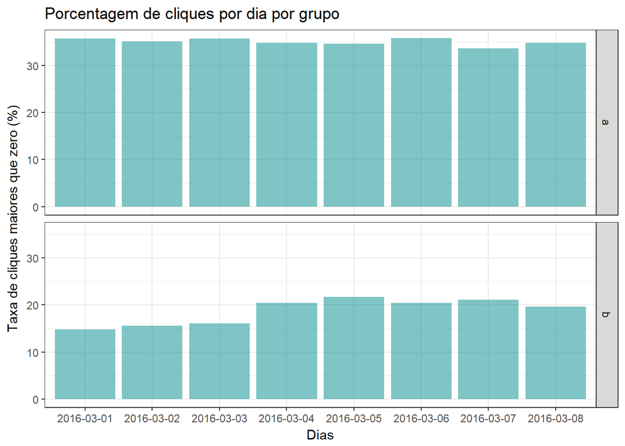

```r
taxa_cliques_group %>%
  filter(num_clicks > 0) %>%
  ggplot(aes(x = date, y =  taxa_cliques_group )) +
  geom_col(fill = "darkcyan", alpha = .5) +
  facet_grid(group ~ .) +
  labs(title="Porcentagem de cliques por dia por grupo",
       x="Dias",
       y="Taxa de cliques maiores que zero (%)")
```

#### Quais resultados as pessoas tendem a tentar primeiro? Como isso muda no dia-a-dia?

Para responder a essa pergunta, vamos analisar o relacionamento das colunas *results* e *first_click*. Podemos ver que há uma concentração de pontos na faixa de valores entre 0 e 25 no eixo da variável *first_click*, o que nos leva a acreditar que os usuários tendem a tentar primeiro os primeiros reultados da busca. Há mais alguns pontos extremos, onde os usuários clicam primeiro no resultado que fica em posições maiores, mas não são a maioria.

Aqui, a marca utilizada foi o ponto. Cada ponto é uma observação que relaciona as variáveis representadas pelos canais horizontal e vertical, no caso, o primeiro clique e o número de resultados, respectivamente. A marca utilizada não ajuda muito a saber a quantidade exata de ocorrências em determinada faixa de valor, ou seja, a variável *quantidade* não está sendo exibida no canal correto nesse caso. Então não conseguimos responder muito bem à pergunta proposta, mas o gráfico serve para visualizar onde a maior parte dos dados está concentrada.

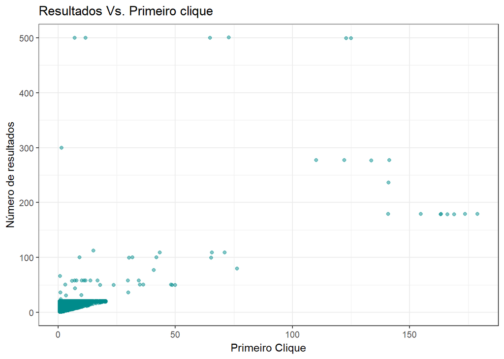

```r
buscas  %>%
  filter(!is.na(first_click)) %>%
  ggplot(aes(x = first_click, y = results )) +
  geom_jitter(alpha = .5, color = "darkcyan") +
  labs(title="Resultados Vs. Primeiro clique",
       x="Primeiro Clique",
       y="Número de resultados")
```

Para responder ainda melhor à pergunta, vamos analisar em um gráfico diferente. Para facilitar a visualização, vamos filtrar os dados de *first_click* menores que 25, pois vimos que é onde os dados concentram-se, então isso não prejudicará a conclusão nesse caso. Assim, podemos ver abaixo uma barra para cada valor de *first_click*, onde a primeira barra é referente ao valor *1*, a segunda referente ao valor *2*, e assim por diante.

Com base nessas informações, podemos dizer que os usuários tendem a tentar primeiro os resultados que ficam até a 5ª, ou 6ª ou até 7ª posições. Se quisermos ser ainda mais específicos, dizemos que os usuários tendem a tentar primeiro os resultados da primeira posição, pois é a posição onde a barra está mais alta no gráfico abaixo.

Utilizando a coluna como marca e colocando a variável *quantidade* no canal vertical, podemos ver como mais clareza a resposta da pergunta.

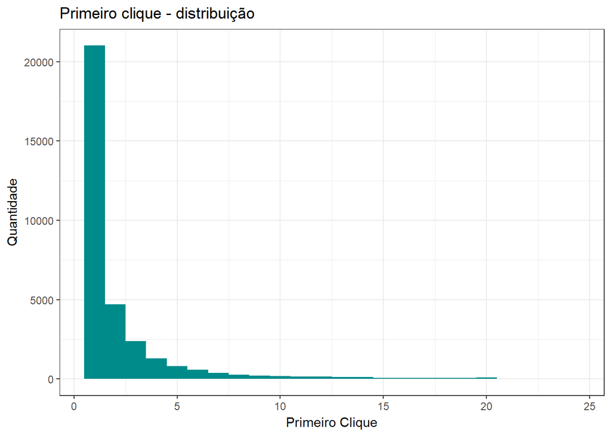

```r
buscas  %>%
  filter(!is.na(first_click) & first_click < 25) %>%
  ggplot(aes(x = first_click)) +
  geom_histogram(binwidth = 1, fill = "darkcyan") +
  labs(title="Primeiro clique - distribuição",
       x="Primeiro Clique",
       y="Quantidade")
```

Agora, se fizermos a mesma análise e separarmos os resultados por dia, chegaremos às mesmas conclusões anteriores. Isso porque, na visualização abaixo, podemos ver que as barras em cada gráfico estão basicamente no mesmo formato das barras do gráfico anterior, e por equivalência, os gráficos abaixo também são parecidos entre si.

Aqui, temos as mesmas marcas e canais da visualização anterior, e inserimos outra variável que é o *dia*. As informações de cada dia são exibidas em gráficos diferentes - e com cores diferentes, apesar de não ser necessário, mas fica mais bonito :).

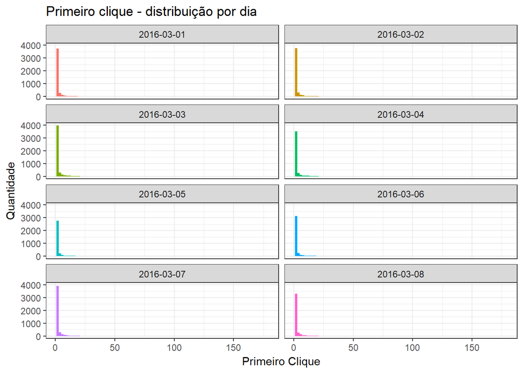

```r
buscas  %>%
  filter(!is.na(first_click)) %>%
  arrange(date) %>%
  ggplot(aes(x =  first_click, fill = date )) +
  geom_histogram(binwidth = 2)  +
  facet_wrap(~ date, ncol = 2) +
  labs(title="Primeiro clique - distribuição por dia",
       x="Primeiro Clique",
       y="Quantidade") +
   theme(legend.position="none")
```

#### Qual é a taxa de resultados zero no geral? Como isso varia entre os grupos?

O gráfico abaixo responde à primeira pergunta. Podemos observar que a altura da barra vai até 18.48% que é a taxa de pesquisas que não retornaram nenhum resultado. Essa taxa está considerando todos os dias de dados para os dois grupos presentes *a* e *b*.

As duas variáveis de interesse estão codificadas nos dois canais principais, e isso facilita muito a visualização da informação. Aqui foram usados a coluna e o texto representando a taxa como marcas. O texto proporciona a visualização do valor exato da altura da coluna.

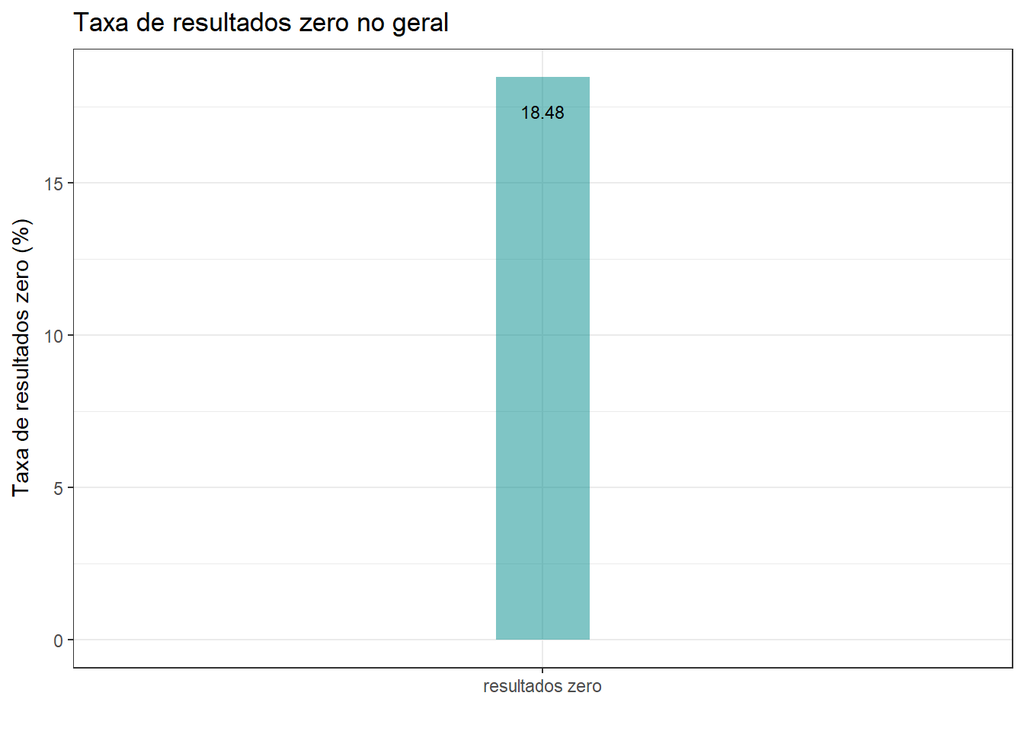

```r
taxa_res <- buscas %>%
  group_by(results) %>%
  summarise(n = n()) %>%
  mutate(taxa_res = n / sum(n) * 100)


taxa_res %>%
  filter(results == 0) %>%
  ggplot(aes(x= "resultados zero", y = taxa_res )) +
  geom_col(width = .1, alpha = .5, fill = "darkcyan") +
  geom_text(aes(label = signif(taxa_res, digits = 4)), size = 3, hjust = 0.5, vjust = 3, position = "stack") +
   labs(title="Taxa de resultados zero no geral",
       x="",
       y="Taxa de resultados zero (%)")
```

Quando separamos os grupos para responder à segunda pergunta, obtemos os resultados apresentaados abaixo. Podemos ver que há uma pequena diferença nas taxas de pesquisas que retornaram nenhum resultado. O grupo *a* retornou um pouco menos de resultados vazios: 18.42%, enquanto que no grupo *b*, 18.62% das pesquisas realizadas não retornaram resultados.

Novamente, as duas informações principais estão codificadas nos canais principais, facilitando a visualização. Novamente, a coluna e o texto representando a taxa foram usados como marcas.O texto proporciona a visualização do valor exato da altura da coluna.

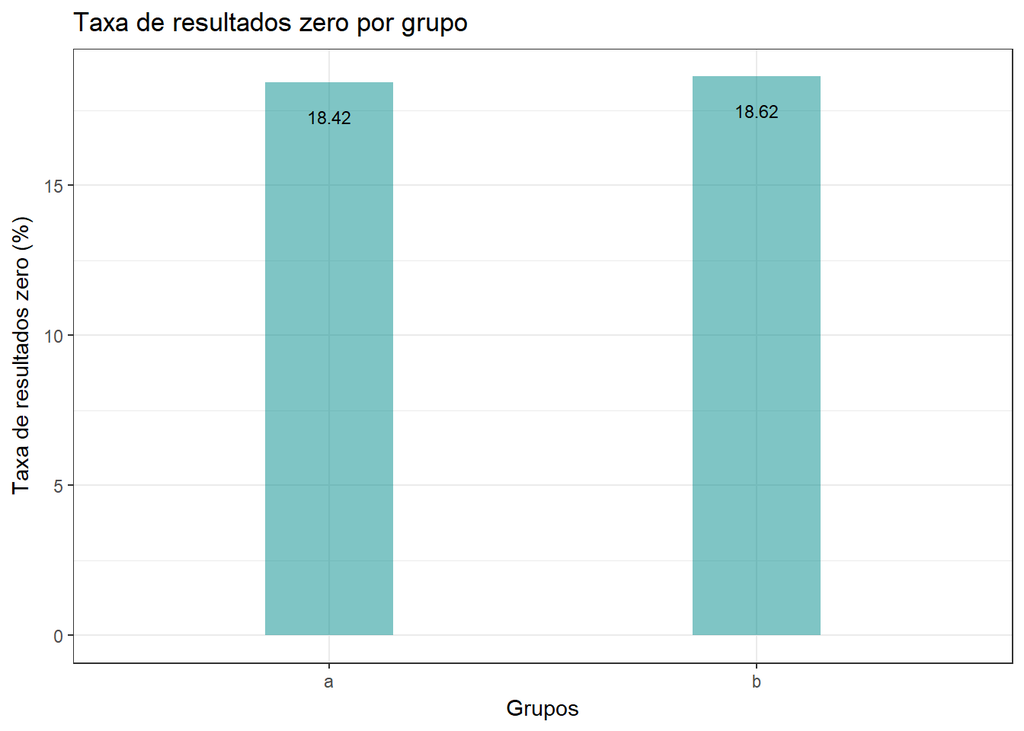

```r
taxa_res_group <- buscas %>%
  group_by(group, results) %>%
  summarise(n = n()) %>%
  mutate(taxa_res_group = n / sum(n) * 100)

taxa_res_group %>%
  filter(results == 0) %>%
  ggplot(aes(x = group, y = taxa_res_group )) +
  geom_col(width = .3, alpha = .5, fill = "darkcyan") +
  geom_text(aes(label = signif(taxa_res_group, digits = 4)), size = 3, hjust = 0.5, vjust = 3, position = "stack") +
   labs(title="Taxa de resultados zero por grupo",
       x="Grupos",
       y="Taxa de resultados zero (%)")
```

#### A duração da sessão é aproximadamente o tempo entre o primeiro e o último evento de uma sessão. Escolha uma variável do conjunto de dados e descreva sua relação com o tamanho da sessão. Visualize o relacionamento.

Criamos a variável de duração da sessão fazendo a diferença entre o último *session_end_date* e o primeiro *session_start_date* para cada sessão dos dados, representada pela coluna *session_id*. A variável grupo foi a escolhida para ser relacionda com a duração da sessão.

Abaixo, vamos o gráfico que relaciona as duas. A escala do eixo y, que representa o tempo em minutos de duração da sessão, foi modificada em escala logaritmica para facilitar a visualização.

Como marca foram usados pontos. Os canais principais contém as duas principais informações - *duração da sessão* e *grupos*. Os grupos também são identificados pelo canal da cor, onde cada cor é um grupo diferente.

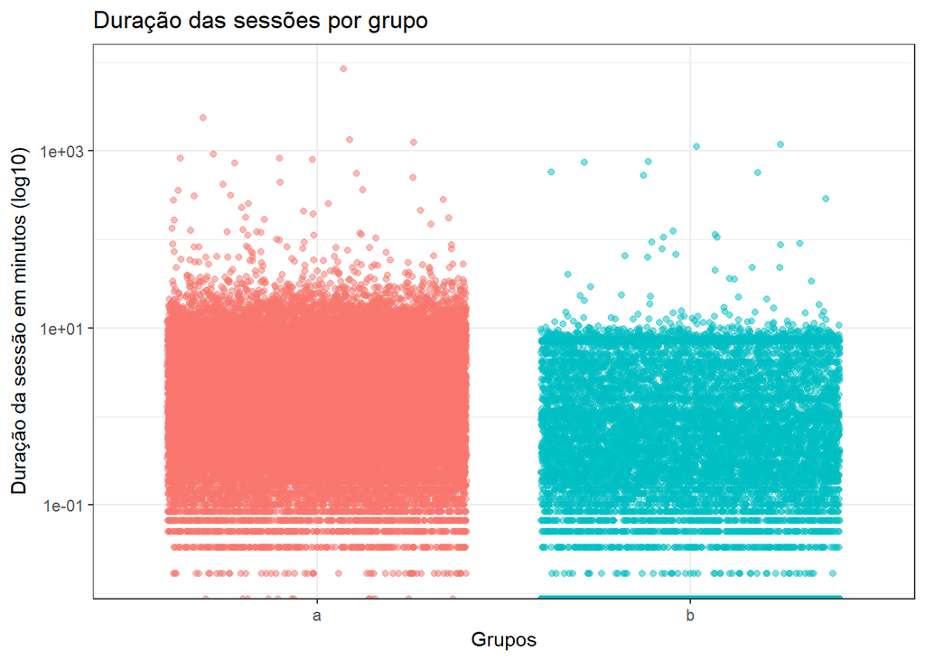

```r
duracao_sessao <- buscas %>%
  arrange(session_start_date) %>%
  group_by(session_id, group) %>%
  summarise(
    duracao_sessao = difftime(last(session_end_date), first(session_start_date), tz = "UTC", units="mins")) %>%
  mutate(duracao_sessao = as.numeric(duracao_sessao))

duracao_sessao %>%
  ggplot(aes(x = group, y = duracao_sessao)) +
  geom_jitter(alpha = .5, aes(col = group)) +
  scale_y_log10() +
   labs(title="Duração das sessões por grupo",
       x="Grupos",
       y="Duração da sessão em minutos (log10)") +
  theme(legend.position="none")
```

Mais informações sobre marcas e canais: https://prezi.com/qblrmexbxhqd/visualizacao-parte-2-marcas-e-canais/